# Image_segmentation_devils_final

Methods Description:

We extracted tumor location and size of each diseased devil from available photos and field records known as devil fundamental sheets that were taken by field ecologists during their field work between 2003-2019. These fundamental sheets provide exact measurements of the length and width of each tumor as well as a rough sketch of its location on schematic representations of the devil face (front, left, right) and body (dorsal, ventral). Using this information and photos taken of the tumors of each devil, we drew the contours of the tumors onto blank versions of these devil facial and body diagrams with a drawing pad to refine the map of tumor locations in diseased devils.

We generated a custom python script to stack the tumor contour diagrams of the diseased devils to quantify the density of tumor occurrence across the devil face and body.

```python
# Libraries needed
import os
from mpl_toolkits.mplot3d import Axes3D
from matplotlib import cm, colors
import matplotlib.pyplot as plt
import cv2
import numpy as np


# Functions Needed
def image_extract(filename, outdir):
    devil=cv2.imread(filename)
    r, g, b = cv2.split(devil)

    pixel_colors = devil.reshape((np.shape(devil)[0]*np.shape(devil)[1], 3))
    norm = colors.Normalize(vmin=-1.,vmax=1.)
    norm.autoscale(pixel_colors)
    pixel_colors = norm(pixel_colors).tolist()

    hsv_devil = cv2.cvtColor(devil, cv2.COLOR_RGB2HSV)
    h, s, v = cv2.split(hsv_devil)

    light_orange = (1, 120, 110)
    dark_orange = (30, 255, 255)


    mask = cv2.inRange(hsv_devil, light_orange, dark_orange)
    result = cv2.bitwise_and(devil, devil, mask=mask)


    #Check color thresholds extraction
    #lo_square = np.full((10, 10, 3), light_orange, dtype=np.uint8) / 255.0
    #do_square = np.full((10, 10, 3), dark_orange, dtype=np.uint8) / 255.0

    #Check Image Extraction
    #maskfile=os.path.basename(os.path.splitext(filename)[0]) +"masked.png"
    #plt.figure(figsize=(20, 8))
    #plt.subplot(1, 3, 1)
    #plt.imshow(devil)
    #plt.subplot(1, 3, 2)
    #plt.imshow(result)
    #plt.savefig(os.path.join(outdir, maskfile), bbox_inches='tight')

    return result



def ref_extract(filename):
    ref=cv2.imread(filename)
    img = cv2.cvtColor(ref, cv2.COLOR_BGR2GRAY)
    _,alpha = cv2.threshold(img,254,255,cv2.THRESH_BINARY_INV)
    b, g, r = cv2.split(ref)
    rgba = [b,g,r, alpha]
    dst = cv2.merge(rgba,4)
    return dst


def devil_plot(aggregate_file, devil_ref, vmin_man, vmax_man, pltcolor='Blues',colorcut=10, line = .3):
    cmap = cm.get_cmap(pltcolor, colorcut)    # 11 discrete colors
    plt.figure(figsize=(20, 8))
    plt.imshow(aggregate_file/255, cmap, vmin = vmin_man, vmax = vmax_man)
    plt.colorbar()
    plt.imshow(devil_ref)
    #ax=plt.gca()
    plt.grid(linestyle='-', linewidth=line, color='white')


def devil_plotnoaxis(aggregate_file, devil_ref, vmin_man, vmax_man, pltcolor='Blues',colorcut=10):
    cmap = cm.get_cmap(pltcolor, colorcut)    # 11 discrete colors
    plt.figure(figsize=(20, 8))
    plt.imshow(aggregate_file/255, cmap, vmin = vmin_man, vmax = vmax_man)
    plt.colorbar()
    plt.imshow(devil_ref)
    #ax=plt.gca()
    plt.grid()
    plt.axis('off')
```

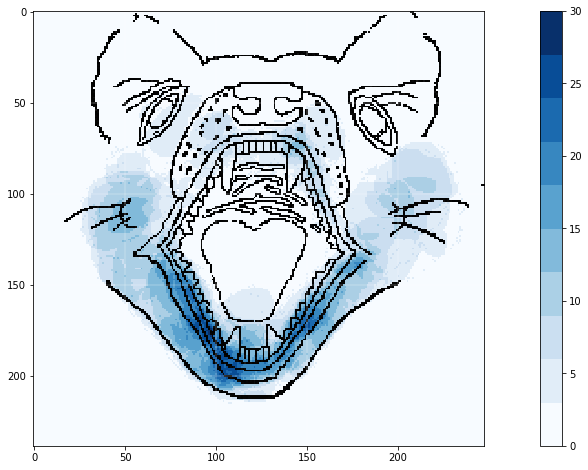

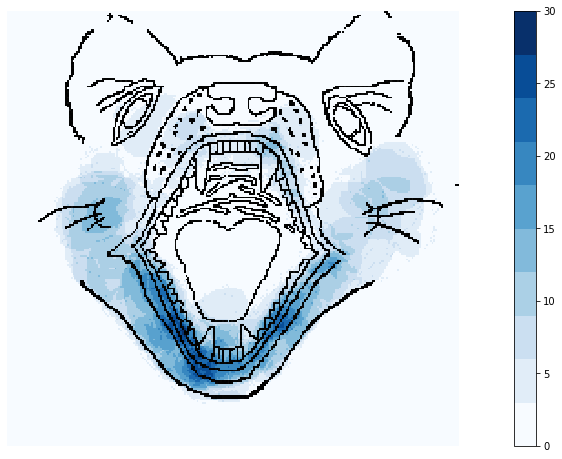

```python
# Front Face
outdir = '/Users/labby/Desktop/Devil_paper/face_masks'
indir = "/Users/labby/Downloads/Front_Face_All/"
ref_filename='/Users/labby/Downloads/Blank Fundamentals_backside1.png'

#os.mkdir(outdir)


extracted = []
for filename in os.listdir(indir):
    #print(filename)
    filepath=os.path.join(indir, filename)
    result=image_extract(filepath, outdir)
    extracted.append(result)



aggregate_file = extracted[(len(extracted)-1)].sum(axis=2)
for i in range((len(extracted)-1)):
    aggregate_file = aggregate_file+extracted[i].sum(axis=2)


devil = ref_extract(ref_filename)

f = devil_plot(aggregate_file, devil, vmin_man=0, vmax_man = 30)
plt.savefig("/Users/labby/Desktop/Devil/foo.pdf", bbox_inches='tight')

#devil_plot(aggregate_file, devil, pltcolor = "Blues", vmin_man=0, vmax_man = 30, line = .5)
devil_plotnoaxis(aggregate_file, devil,vmin_man=0, vmax_man = 30)
```

We know that the dimensions of the picture is on the y-axis:[0-239] and x-axis:[0-248]. The best grid structure appears to be when we divide everything by 15. I'm assuming that the "lower jaw" is where the split in the mouth occurs (around 133-135). Noticeably, the diagram is not symmetrical along the vertical axis which proves to be a bit challenging of what to consider as "left" vs "right". However, as this is not the purpose of the analysis, we will keep it simple, and only define "upper" vs "lower". The question remains, which sections to include? And How to normalize? We can pixelate this/section the image and take the maximum count for each section. In other words, a binary count. Then we average across all sections we decide to include in the count for the "upper" and the "lower". Ideally, I would find the contour of the devil's face, and then do a subtraction, but it would require that I go back to photoshop, color in the devil's face, and then import back.

```
Dimensions of picture
```

```
(239, 248)
```

[figure not shown]

[figure not shown]

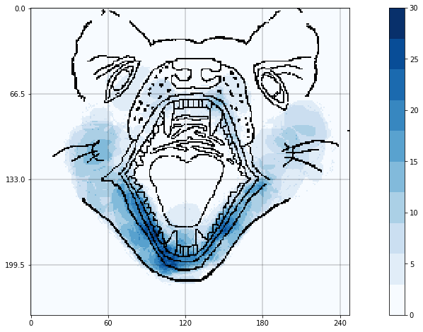

[figure not shown]

[figure not shown]

```python
# Segment the image
def devil_plot(aggregate_file, devil_ref, vmin_man, vmax_man, xbreak, ybreak, pltcolor='Blues',colorcut=10, line = .3):
    cmap = cm.get_cmap(pltcolor, colorcut)    # 11 discrete colors
    plt.figure(figsize=(20, 8))
    plt.imshow(aggregate_file/255, cmap, vmin = vmin_man, vmax = vmax_man)
    plt.yticks(np.arange(0, 239, ybreak))
    plt.xticks(np.arange(0, 248, xbreak))
    plt.colorbar()
    plt.imshow(devil_ref)
    #ax=plt.gca()
    plt.grid(linestyle='-', linewidth=line, color='black')

devil = ref_extract(ref_filename)

f = devil_plot(aggregate_file, devil, vmin_man=0, vmax_man = 30, xbreak=15, ybreak=15)
plt.savefig("/Users/labby/Desktop/Devil/ref_grids_120x_135y_250_15.pdf", bbox_inches='tight')


f = devil_plot(aggregate_file, devil, vmin_man=0, vmax_man = 30, xbreak=120, ybreak=133)
plt.savefig("/Users/labby/Desktop/Devil/ref_grids_120x_133y_250_5.pdf", bbox_inches='tight')



f = devil_plot(aggregate_file, devil, vmin_man=0, vmax_man = 30, xbreak=120/2, ybreak=133/2)
plt.savefig("/Users/labby/Desktop/Devil/ref_grids_120-2x_135-2y.pdf", bbox_inches='tight')




f = devil_plot(aggregate_file, devil, vmin_man=0, vmax_man = 30, xbreak=120/3, ybreak=133/3)
plt.savefig("/Users/labby/Desktop/Devil/ref_grids_120-3x_135-3y.pdf", bbox_inches='tight')



f = devil_plot(aggregate_file, devil, vmin_man=0, vmax_man = 30, xbreak=120/4, ybreak=133/4)
plt.savefig("/Users/labby/Desktop/Devil/ref_grids_120-4x_133-4y.pdf", bbox_inches='tight')

print('Dimensions of picture')
aggregate_file.shape
```

With every increase in the number of rows and columns in the matrix, we see a significant increase in the number of sections. For simplicity's sake, I've decided that subsectioning the image into 4 pieces on each axes is the simplest.

Which ones are included? Coordinates for the top right of each box of the 3rd image: Let's round 199.5 to 199. And 66.5 to 66. L1. [60:120, 199:239] L2. [120:180, 199:239] L3. [0:60, 133:199] L4. [60:120, 133:199] L5. [120:180, 133:199] L6. [180:240, 133:199]

U1. [0:60, 66:133] U2. [60:120, 66:133] U3. [120:180, 66:133] U4. [180:240, 66:133] U5. [60:120, 0:66] U6. [120:180, 0:66]

```python
def sec_count(df):
    ct =round(max([y for x in df for y in x])/255)
    return ct

L1 = aggregate_file[199:239, 60:120]
L2 = aggregate_file[133:199, 0:60]
L3 = aggregate_file[133:199, 60:120]
L4 = aggregate_file[199:239, 120:180]
L5 = aggregate_file[133:199, 120:180]
L6 = aggregate_file[133:199, 180:240]

U1 = aggregate_file[66:133, 0:60]
U2=aggregate_file[66:133, 60:120]
U3=aggregate_file[66:133, 120:180]
U4=aggregate_file[66:133, 180:240]
U5=aggregate_file[0:66, 60:120]
U6=aggregate_file[0:66,120:180]

sclw = [L1, L2, L3, L4, L5, L6]
scup = [U1, U2, U3, U4, U5, U6]

sclwmax=[]
scupmax=[]
for i in range((len(sclw))):
    scl=sec_count(sclw[i])
    sclwmax.append(scl)

    scu=sec_count(scup[i])
    scupmax.append(scu)

print(sclwmax)
print(scupmax)
```

```
[26.0, 14.0, 28.0, 20.0, 25.0, 18.0]
[15.0, 15.0, 14.0, 13.0, 9.0, 9.0]
```

```
Upper Side
Lower Side
```

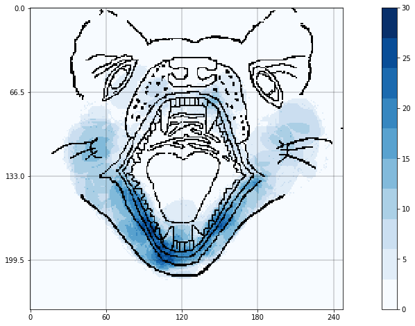

[figure not shown]

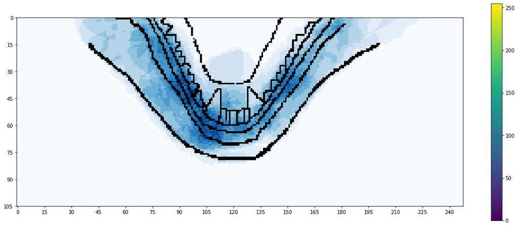

```python
f = devil_plot(aggregate_file, devil, vmin_man=0, vmax_man = 30, xbreak=120/2, ybreak=133/2)
plt.savefig("/Users/labby/Desktop/Devil/ref_grids_120-2x_135-2y.pdf", bbox_inches='tight')



# Check that the upper is the upper:
print("Upper Side")
plt.figure(figsize=(20, 8))
cmap = cm.get_cmap("Blues", 11)
plt.imshow(aggregate_file[0:133, :]/255, cmap, vmin = 0, vmax = 30)
plt.yticks(np.arange(0, 133, 15))
plt.xticks(np.arange(0, 248, 15))
plt.colorbar()
plt.imshow(devil[0:133, :])

print("Lower Side")
plt.figure(figsize=(20, 8))
cmap = cm.get_cmap("Blues", 11)
plt.imshow(aggregate_file[133:239, :]/255, cmap, vmin = 0, vmax = 30)
plt.imshow(devil[133:239, :])
plt.yticks(np.arange(0, 106, 15))
plt.xticks(np.arange(0, 248, 15))
plt.colorbar()
```

These shows that the correct sections have been defined. Ignore the new axes as they are not informative for these particular plots. For now, we will take the mean of these sections. It's hard, with the small sample size, to choose the appropriate test. I would choose the non-parametric Mann-Whitney U Test, but online, people have mentioned using the parametric t.test which I've put down below. Both results are significant with p-value < 0.05.

```python
print("Lower")
print(sum(sclwmax)/6)

print("Upper")
print(sum(scupmax)/6)
```

```
Lower
21.833333333333332
Upper
12.5
```

```python
import pandas as pd

joinedlist = sclwmax + scupmax
data = {'Face':['Lower', 'Lower', 'Lower', 'Lower','Lower', 'Lower', 'Upper','Upper', 'Upper', 'Upper', 'Upper', 'Upper'],
        'Counts': joinedlist
       }
df = pd.DataFrame(data,columns= ['Face', 'Counts'])
```

```
MannwhitneyuResult(statistic=2.5, pvalue=0.007875821410533794)
Ttest_indResult(statistic=3.7652642921677377, pvalue=0.0036901174725822166)
```

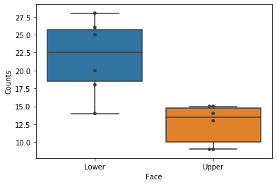

```python
import seaborn as sns
ax = sns.boxplot(x="Face", y="Counts", data=df)
ax = sns.swarmplot(x="Face", y="Counts", data=df, color=".25")

from scipy import stats
print(stats.mannwhitneyu(sclwmax,scupmax))
print(stats.ttest_ind(sclwmax,scupmax))
```

[figure not shown]

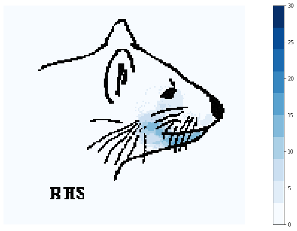

```python
# RHS
outdir = '/Users/labby/Desktop/Devil_paper/face_masks'
indir = "/Users/labby/Downloads/RHS_only/"
ref_filename='/Users/labby/Downloads/RHS_face_(blue)1.png'

#os.mkdir(outdir)


extracted = []
for filename in os.listdir(indir):
    #print(filename)
    filepath=os.path.join(indir, filename)
    result=image_extract(filepath, outdir)
    extracted.append(result)



aggregate_file = extracted[(len(extracted)-1)].sum(axis=2)
for i in range((len(extracted)-1)):
    aggregate_file = aggregate_file+extracted[i].sum(axis=2)


devil = ref_extract(ref_filename)
plt.figure(figsize=(8, 5))
devil_plot(aggregate_file, devil, vmin_man=0, vmax_man = 30)
plt.savefig("/Users/labby/Desktop/Devil/rhs.pdf", bbox_inches='tight')


#devil_plot(aggregate_file, devil, pltcolor = "Blues", vmin_man=0, vmax_man = 30)
devil_plotnoaxis(aggregate_file, devil, vmin_man=0, vmax_man = 30)
```

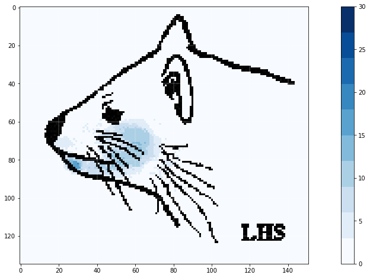

[figure not shown]

```python
# LHS
outdir = '/Users/labby/Desktop/Devil_paper/face_masks'
indir = "/Users/labby/Downloads/LHS_only/"
ref_filename='/Users/labby/Downloads/LHS Face_(blue)1.png'

#os.mkdir(outdir)


extracted = []
for filename in os.listdir(indir):
    #print(filename)
    filepath=os.path.join(indir, filename)
    result=image_extract(filepath, outdir)
    extracted.append(result)



aggregate_file = extracted[(len(extracted)-1)].sum(axis=2)
for i in range((len(extracted)-1)):
    aggregate_file = aggregate_file+extracted[i].sum(axis=2)


devil = ref_extract(ref_filename)
plt.figure(figsize=(8, 5))
devil_plot(aggregate_file, devil, vmin_man=0, vmax_man = 30)
plt.savefig("/Users/labby/Desktop/Devil/lhs.pdf", bbox_inches='tight')


#devil_plot(aggregate_file, devil, pltcolor = "Blues", vmin_man=0, vmax_man = 30)
devil_plotnoaxis(aggregate_file, devil, vmin_man=0, vmax_man = 30)
```

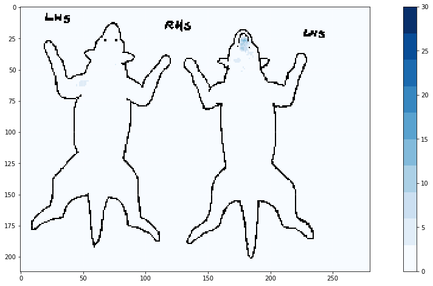

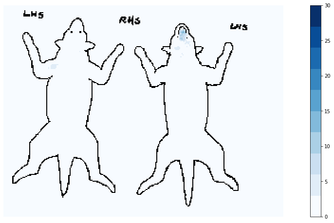

```python
# LHS
outdir = '/Users/labby/Desktop/Devil_paper/face_masks'
indir = "/Users/labby/Downloads/FullBody_only/"
ref_filename='/Users/labby/Downloads/Body_(blue)1.png'

#os.mkdir(outdir)


extracted = []
for filename in os.listdir(indir):
    #print(filename)
    filepath=os.path.join(indir, filename)
    result=image_extract(filepath, outdir)
    extracted.append(result)



aggregate_file = extracted[(len(extracted)-1)].sum(axis=2)
for i in range((len(extracted)-1)):
    aggregate_file = aggregate_file+extracted[i].sum(axis=2)


devil = ref_extract(ref_filename)
devil_plot(aggregate_file, devil, vmin_man=0, vmax_man = 30)
#devil_plot(aggregate_file, devil, pltcolor = "Blues", vmin_man=0, vmax_man = 30)
devil_plotnoaxis(aggregate_file, devil, vmin_man=0, vmax_man = 30)
```